# Fourth Week: Hypothesis Testing

TIMSS Analysis

student name

2018-03-09 03:00:45

# تمرین سری چهارم: چقدر ریاضی بلدیم و چرا؟

لطفا مقاله زیر را مطالعه بفرمایید.

[چرایی رتبه ضعیف ایران در آزمون تیمز](https://goo.gl/gX8DZc)

> با استفاده از داده های ارزیابی تیمز ۲۰۱۵ ادعاهای زیر را مورد ارزیابی قراردهید. برای هر سوال علاوه بر استدلال آماری که در غالب آزمون فرض تعریف می شود از تصویرسازی مناسب باهر دو ابزار ggplot2 و highcharter استفاده نمایید. به دلخواه به هفت گزاره از موارد زیر پاسخ دهید.

```r
library(readr)
library(dplyr)
```

```r
library(tidyr)
library(highcharter)
library(ggplot2)
tims_2015 <- read_rds('E://edu//TahlilDade//timss_2015.rds')
bsa = read_rds("E://edu//TahlilDade//bsa.rds")
bcg = read_rds("E://edu//TahlilDade//bcg.rds")
bsg = read_rds("E://edu//TahlilDade//bsg.rds")
bsr = read_rds("E://edu//TahlilDade//bsr.rds")
bst = read_rds("E://edu//TahlilDade//bst.rds")
btm = read_rds("E://edu//TahlilDade//btm.rds")
bts = read_rds("E://edu//TahlilDade//bts.rds")
```

```r
# this is a data.frame of teacher-student
student_teacher <- bst %>% select(idcntry, idteach, idstud)
# this data.frame is student-mathability
student_math <- bsa %>% select(idcntry, idstud, bsmmat01, bsmmat02, bsmmat03, bsmmat04, bsmmat05) %>%
  group_by(idcntry, idstud) %>% summarise(math_score = (bsmmat01+bsmmat02+bsmmat03+bsmmat04+bsmmat05)/5)
```

۱. میران رضایت معلمان در پیشرفت تحصیلی دانش آموزان موثر است.

```r
btm %>% select(idcntry, idteach, sat = btbg10b) -> teach.sat
full_join(student_teacher, student_math) %>% right_join(teach.sat)-> sat.sc
sat.sc %>% .[complete.cases(.),]->sat.sc
aov(math_score~sat, data = sat.sc) %>% summary.aov()
```

```
##                 Df    Sum Sq Mean Sq F value Pr(>F)
## sat              1 7.425e+06 7424600   688.8 <2e-16 ***
## Residuals   317634 3.424e+09   10779
## ---
## Signif. codes:  0 '***' 0.001 '**' 0.01 '*' 0.05 '.' 0.1 ' ' 1
```

As we can see Null hypothesis of no difference in mean between groups is highyl REJECTED.

```r
sat.sc %>% group_by(sat) %>% summarise(sc = mean(math_score)) -> sat.sc.mean
hchart(sat.sc.mean, type = "line", hcaes(x = as.factor(sat), y = sc))
```

[interactive chart not shown]

***

۲. والدینی که تحصیلات بیشتری دارند دارای فرزندان موفق تری می باشند.

```r
bsg %>% select(idcntry, idstud, m = bsbg07a, f = bsbg07b)%>% filter(m != 8 & f != 8) %>%
  mutate(edu = m+f) %>%
  select(idcntry, idstud, edu) ->p.e


full_join(p.e, student_math) %>% .[complete.cases(.),]-> s.p
aov(math_score~edu, s.p)->fit_q2
summary.aov(fit_q2)
```

```
##                 Df    Sum Sq   Mean Sq F value Pr(>F)
## edu              1 2.799e+08 279854509   27876 <2e-16 ***
## Residuals   168494 1.692e+09     10039
## ---
## Signif. codes:  0 '***' 0.001 '**' 0.01 '*' 0.05 '.' 0.1 ' ' 1
```

As we can see Null hypothesis of no difference in mean between groups of parent education is highly REJECTED.

```r
s.p %>% group_by(edu) %>% summarise(sc = mean(math_score)) -> s.p.mean
hchart(s.p.mean, type = "line", hcaes(x = as.factor(edu), y = sc))
```

[interactive chart not shown]

***

۳. امکانات رفاهی در خانه موجب پیشرفت تحصیلی می گردد.

۴. محیط آرام مدرسه نقش مهمی در پیشرفت تحصیلی دارد.

۵. معلمان با تحصیلات بالاتر یا تجربه بیشتر دانش آموزان موفق تری تربیت می کنند.

```r
btm %>% select(idcntry, idteach,years = btbg01 ,teacher_edu = btbg04) -> teacher_level
teacher_level %>% .[complete.cases(.),] -> teacher_level
left_join(student_math, student_teacher) -> st_math_tea
right_join(st_math_tea, teacher_level) -> st_math_tea_lev
as.data.frame(st_math_tea_lev) -> st_math_tea_lev
```

## Education of Teacher

Null Hypothesis: score means between students of different level of educations are all the same. Alternative: means are different

```r
aov(math_score~teacher_edu, st_math_tea_lev)-> fit
summary.aov(fit)
```

```
##                 Df    Sum Sq   Mean Sq F value Pr(>F)
## teacher_edu      1 1.513e+08 151344453   14911 <2e-16 ***
## Residuals   297443 3.019e+09     10150
## ---
## Signif. codes:  0 '***' 0.001 '**' 0.01 '*' 0.05 '.' 0.1 ' ' 1
```

As we can see the Null Hypothesis get rejected in favor of alternative hypothesis. but can we see what is the impact of education of teacher?

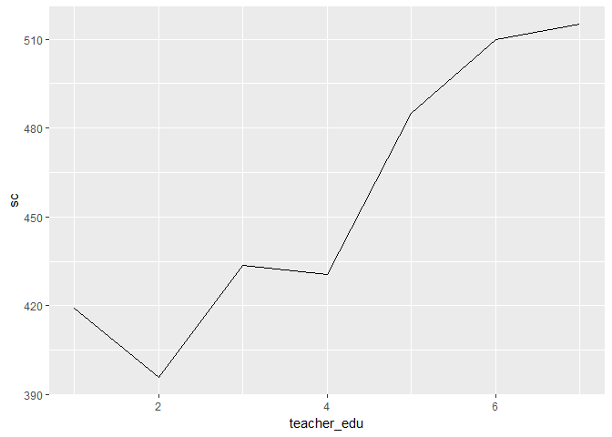

```r
st_math_tea_lev %>% group_by(teacher_edu) %>% summarise(sc = mean(math_score)) -> edu_math
ggplot(edu_math)+geom_line(aes(x = teacher_edu, y = sc))
```

So as we can see overally the higher the education of the teacher the higher the score. but we know it is not because of noise because of very small p-value we get.

## Experience of teacher

Null Hypothesis: score means between students of different level of experiences are all the same. Alternative: means are different

```r
aov(math_score~years, st_math_tea_lev)-> fit
summary.aov(fit)
```

```
##                 Df    Sum Sq Mean Sq F value Pr(>F)
## years            1 6.164e+06 6163830   579.4 <2e-16 ***
## Residuals   297443 3.164e+09   10638
## ---
## Signif. codes:  0 '***' 0.001 '**' 0.01 '*' 0.05 '.' 0.1 ' ' 1
```

As we can see the Null Hypothesis get rejected in favor of alternative hypothesis. but can we see what is the impact of experience of teacher? We will divide ranges to decades of experience.

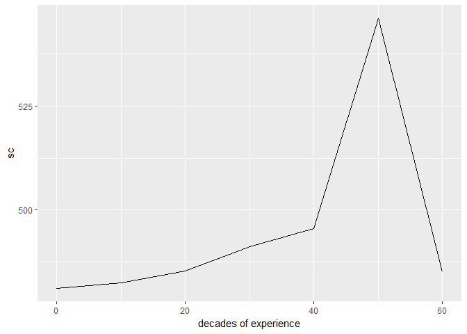

```r
st_math_tea_lev %>% mutate(years = round(years, digits = -1))->st_math_tea_lev
st_math_tea_lev %>% group_by(years) %>% summarise(sc = mean(math_score)) -> edu_math
ggplot(edu_math)+geom_line(aes(x = years, y = sc))+labs(x = "decades of experience")
```

```r
aov(math_score~years*teacher_edu, st_math_tea_lev)-> fit
summary.aov(fit)
```

```
##                       Df    Sum Sq   Mean Sq  F value   Pr(>F)
## years                  1 5.588e+06   5587914   553.15  < 2e-16 ***
## teacher_edu            1 1.596e+08 159581072 15796.94  < 2e-16 ***
## years:teacher_edu      1 3.648e+05    364787    36.11 1.87e-09 ***
## Residuals         297441 3.005e+09     10102
## ---
## Signif. codes:  0 '***' 0.001 '**' 0.01 '*' 0.05 '.' 0.1 ' ' 1
```

As we can see the two way anova test tells us: No interaction between experience years and level of education is rejected. No diffrence between mean of different groups of experience years is rejected. No diffrence bettwen mean of different groups of education level is rejected.

۶. پسران در کاربرد هندسه قوی تر هستند.

```r
tims_2015 %>% filter(cognitive_domain == 'Applying', content_domain == 'Geometry') %>%
  mutate(cf = correct_ratio_per_question_female, cm = correct_ratio_per_question_male) %>%
  select(q = question, cf, cm) %>%
  group_by(q) %>%
  summarise(f = mean(cf), m = mean(cm)) %>%
  select(q, f, m) %>%
  tidyr::gather('m', 'f', key = 'gender', value = 'math_score') -> ge.sc

t.test(math_score~gender, ge.sc, alt = "greater")
```

```
##
##  Welch Two Sample t-test
##
## data:  math_score by gender
## t = 0.070752, df = 41.969, p-value = 0.472
## alternative hypothesis: true difference in means is greater than 0
## 95 percent confidence interval:
##  -0.05946227         Inf
## sample estimates:
## mean in group f mean in group m
##       0.4112235       0.4086124
```

```r
ge.sc %>% group_by(gender) %>% summarize(sc = mean(math_score)) -> ge
hchart(ge, type = "column", hcaes(x = gender, y = sc))
```

[interactive chart not shown]

As we can see the NULL Hypothesis of Equality between male and female in Applying Geometry can not be REJECTED by the data. ***

۷. تغذیه دانش آموزان نقش اساسی در یادگیری آنها دارد.

```r
bsg %>% select(idcntry, idstud, food = bsbg12) ->stu.food
left_join(stu.food, student_math) -> stu.food
stu.food %>% .[complete.cases(.),] -> stu.food
aov(math_score~food, stu.food) -> fit
summary.aov(fit)
```

```
##                 Df    Sum Sq  Mean Sq F value Pr(>F)
## food             1 3.265e+07 32653399    2940 <2e-16 ***
## Residuals   276078 3.066e+09    11105
## ---
## Signif. codes:  0 '***' 0.001 '**' 0.01 '*' 0.05 '.' 0.1 ' ' 1
```

As we can see the Null Hypothesis of same mean between types for breakfast consumption is REJECTED. but how is the relation. As you can see a weird result.

```r
stu.food.mean <- stu.food %>% group_by(food)%>% summarise(sc = mean(math_score))
stu.food.mean <- as.data.frame(stu.food.mean)
hchart(stu.food.mean, type = "line", hcaes(x = as.factor(food), y = sc))
```

[interactive chart not shown]

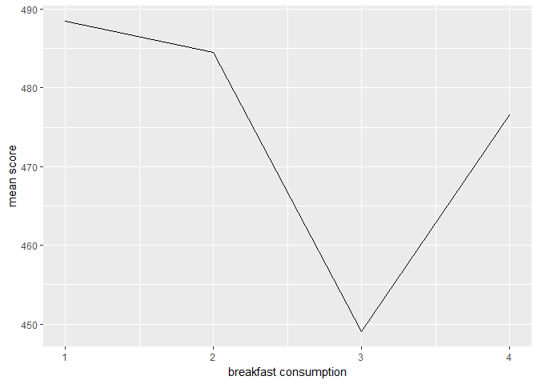

```r
ggplot(stu.food.mean, aes(x = food,y = sc))+geom_line()+labs(x = "breakfast consumption", y = "mean score")
```

۸. مدارس با امکانات بیشتر دارای عملکرد بهتری می باشند.

۹. علت افت تحصیلی عدم مشارکت در کلاس است.

```r
bsg %>% select(idcntry, idstud, class_co = bsbg11) ->stu.co
left_join(stu.co, student_math) -> stu.co
stu.co%>% .[complete.cases(.),] -> stu.co
aov(math_score~class_co, stu.co) -> fit
summary.aov(fit)
```

```
##                 Df    Sum Sq   Mean Sq F value Pr(>F)
## class_co         1 2.648e+08 264849314   25650 <2e-16 ***
## Residuals   264983 2.736e+09     10326
## ---
## Signif. codes:  0 '***' 0.001 '**' 0.01 '*' 0.05 '.' 0.1 ' ' 1
```

As we can see the Null Hypothesis: Class Cooperation is not related with the student educational success is REJECTED. So it has a relatino. let’s see it:

```r
stu.co.mean <- stu.co %>% group_by(class_co)%>% summarise(sc = mean(math_score))
stu.co.mean <- as.data.frame(stu.co.mean)
hchart(stu.co.mean, type = "line", hcaes(x = as.factor(class_co), y = sc))
```

[interactive chart not shown]

***

۱۰. دانش آموزان ایرانی در استدلال قوی تر از کاربرد هستند.

```r
tims_2015 %>%  filter(cognitive_domain == "Reasoning", Country == "Iran, Islamic Rep. of") %>%
  select(q = question, c = correct_ratio_per_question) %>% .[,"c"]-> reason
tims_2015 %>%  filter(cognitive_domain == "Applying", Country == "Iran, Islamic Rep. of") %>%
  select(q = question, c = correct_ratio_per_question) %>% .[,"c"] -> apply
t.test(x = reason, y = apply, var.equal = FALSE, alt = "greater")
```

```
##
##  Welch Two Sample t-test
##
## data:  reason and apply
## t = -2.6374, df = 90.055, p-value = 0.9951
## alternative hypothesis: true difference in means is greater than 0
## 95 percent confidence interval:
##  -0.1131292        Inf
## sample estimates:
## mean of x mean of y
## 0.2540000 0.3233984
```

We

can not

reject the Null Hypothesisa which is iranian students are equal at Reasoning and Applying in favor of alternative of iranian students are better at Reasoning than Applying But:

```r
t.test(x = reason, y = apply, var.equal = FALSE, alt = "less")
```

```
##
##  Welch Two Sample t-test
##
## data:  reason and apply
## t = -2.6374, df = 90.055, p-value = 0.00492
## alternative hypothesis: true difference in means is less than 0
## 95 percent confidence interval:
##         -Inf -0.02566765
## sample estimates:
## mean of x mean of y
## 0.2540000 0.3233984
```

We

can

reject the Null Hypothesisa which is iranian students are equal at Reasoning and Applying in favor of alternative of iranian students are wrose at Reasoning than Applying.

```r
hchart(apply)
```

[interactive chart not shown]

```r
hchart(reason)
```

[interactive chart not shown]

***

سه گزاره جالب کشف کنید و ادعای خود را ثابت نمایید.

## We want to test if owning an own room have a relation with math score.

```r
bsg %>% select(idcntry, idstud, own = bsbg06d) -> s.o
left_join(s.o, student_math)->s.m
s.m %>% .[complete.cases(.),] -> s.m
t.test(math_score~own,s.m)
```

```
##
##  Welch Two Sample t-test
##
## data:  math_score by own
## t = 56.852, df = 158850, p-value < 2.2e-16
## alternative hypothesis: true difference in means is not equal to 0
## 95 percent confidence interval:
##  24.20327 25.93169
## sample estimates:
## mean in group 1 mean in group 2
##        484.9928        459.9254
```

As we can see the Null hypo of no difference is highly REJECTED.

```r
s.m %>% group_by(own) %>% summarise(sc = mean(math_score)) -> s.m
hchart(s.m,type = "column" ,hcaes(x = own, y = sc))
```

[interactive chart not shown]

So people who own their room on average performs better.

## Mother in Country

what is the effect of migrating to math score? let’s see:

```r
bsg %>% select(idcntry, bsbg09a,bsbg09b, idstud, born = bsbg10a) %>%  filter(bsbg09a == 1 & bsbg09b == 1)  -> s.b
left_join(s.b, student_math)->s.b
s.b %>% .[complete.cases(.),] -> s.b
t.test(math_score~born,s.b)
```

```
##
##  Welch Two Sample t-test
##
## data:  math_score by born
## t = 7.8726, df = 2784.9, p-value = 4.934e-15
## alternative hypothesis: true difference in means is not equal to 0
## 95 percent confidence interval:
##  12.97795 21.58701
## sample estimates:
## mean in group 1 mean in group 2
##        474.5518        457.2693
```

So the Null Hypo of No dif is REJECTED. So migration for childs seems to have a negative relation with score.

```r
s.b %>% group_by(born) %>% summarise(sc = mean(math_score)) -> s.b
hchart(s.b,type = "column" ,hcaes(x = born, y = sc)) %>% hc_yAxis(min = 400, max = 500)
```

[interactive chart not shown]

## Effect of Digital Device in home, good or bad?

```r
bsg %>% select(idcntry, idstud, dd = bsbg05) -> s.d
left_join(s.d, student_math)->s.d
s.d %>% .[complete.cases(.),] -> s.d
aov(math_score~dd,s.d)->fit
summary.aov(fit)
```

```
##                 Df    Sum Sq   Mean Sq F value Pr(>F)
## dd               1 1.949e+08 194893883   18558 <2e-16 ***
## Residuals   276057 2.899e+09     10502
## ---
## Signif. codes:  0 '***' 0.001 '**' 0.01 '*' 0.05 '.' 0.1 ' ' 1
```

So having digital devices have effects.

```r
s.d.mean <- s.d %>% group_by(dd)%>% summarise(sc = mean(math_score))
hchart(s.d.mean, type = "line", hcaes(x = as.factor(dd), y = sc))
```

[interactive chart not shown]

So it is mainly good(it is not a good reasoning though, it has high correlation with other things)but too much of it has inverse effect.